# ch05_07_VGG_CatvsDogs(3)_wcolab

## 강아지 vs 고양이 분류하기(3)-VGG16

### 학습 내용

- 강아지와 고양이 데이터를 캐글로 부터 데이터를 준비
- 사전 훈련 모델에 대해 알아봅니다.
- VGG16 모델을 불러와 사용해 봅니다.
  - 데이터 증식을 사용하지 않은 작은 데이터 셋을 활용함.

### 데이터(강아지 vs 고양이)

- url : https://www.kaggle.com/c/dogs-vs-cats/data
- test1.zip : 271.15MB
- train.zip : 543.16MB
- sampleSubmission.csv

### 목차

01. 데이터 준비하기  
02. 사전 훈련된 컨브넷 사용

### 01. 데이터 준비하기

목차로 이동하기

```python
import os, shutil
```

```python
### 드라이브 마운트
from google.colab import drive
drive.mount('/content/drive')
```

```python
# 구글 드라이브에서 데이터 복사
!cp -r '/content/drive/MyDrive/dataset/cats_dogs'  '/content/'
!ls -ls '/content/cats_dogs'
```

```
total 833952
    88 -rw------- 1 root root     88903 Jul 17 16:29 sampleSubmission.csv
277660 -rw------- 1 root root 284321224 Jul 17 16:29 test1.zip
556204 -rw------- 1 root root 569546721 Jul 17 16:29 train.zip
```

```python
# 압축을 풀고, 파일 개수 확인
!rm -rf '/content/datasets/'
!unzip '/content/cats_dogs/test1.zip' -d '/content/datasets/'
!unzip '/content/cats_dogs/train.zip' -d '/content/datasets/'
!ls '/content/datasets/'
!ls -l '/content/datasets/train/' | grep ^- | wc -l
!ls -l '/content/datasets/test1/' | grep ^- | wc -l
```

[output not shown]

[output cut: 4946 more lines]

[output not shown]

```python
# 학습용 25000개, 테스트용 12500
!ls -ltr  '/content/datasets/' | head -10
!ls -ltr  '/content/datasets/train' | tail -10
!ls -ltr  '/content/datasets/test1' | tail -10
```

```
total 1020
drwxr-xr-x 2 root root 770048 Sep 20  2013 train
drwxr-xr-x 2 root root 270336 Sep 20  2013 test1
-rw-r--r-- 1 root root 25671 Sep 20  2013 cat.9937.jpg
-rw-r--r-- 1 root root  3744 Sep 20  2013 cat.9936.jpg
-rw-r--r-- 1 root root 27700 Sep 20  2013 cat.9935.jpg
-rw-r--r-- 1 root root 32621 Sep 20  2013 cat.9999.jpg
-rw-r--r-- 1 root root  9937 Sep 20  2013 cat.9998.jpg
-rw-r--r-- 1 root root 18575 Sep 20  2013 cat.9997.jpg
-rw-r--r-- 1 root root 16855 Sep 20  2013 cat.9996.jpg
-rw-r--r-- 1 root root 13785 Sep 20  2013 cat.9995.jpg
-rw-r--r-- 1 root root 30029 Sep 20  2013 cat.9994.jpg
-rw-r--r-- 1 root root 29133 Sep 20  2013 cat.9993.jpg
-rw-r--r-- 1 root root  5286 Sep 20  2013 12440.jpg
-rw-r--r-- 1 root root 16612 Sep 20  2013 12439.jpg
-rw-r--r-- 1 root root 42306 Sep 20  2013 12438.jpg
-rw-r--r-- 1 root root 20759 Sep 20  2013 12437.jpg
-rw-r--r-- 1 root root 16850 Sep 20  2013 12436.jpg
-rw-r--r-- 1 root root 26283 Sep 20  2013 12435.jpg
-rw-r--r-- 1 root root 29062 Sep 20  2013 12434.jpg
-rw-r--r-- 1 root root 23917 Sep 20  2013 12500.jpg
-rw-r--r-- 1 root root 24012 Sep 20  2013 12499.jpg
-rw-r--r-- 1 root root 21471 Sep 20  2013 12498.jpg
```

```python
!ls -al '/content/datasets/train' | head -5
!ls -l '/content/datasets/train' | grep cat | wc -l
!ls -l '/content/datasets/train' | grep dog | wc -l

!ls -al '/content/datasets/test1' | head -5
!ls -l '/content/datasets/test1' | grep ^- | wc -l
!ls -l '/content/datasets/test1' | grep jpg | wc -l
```

```
total 609260
drwxr-xr-x 2 root root 770048 Sep 20  2013 .
drwxr-xr-x 4 root root   4096 Jul 17 16:29 ..
-rw-r--r-- 1 root root  12414 Sep 20  2013 cat.0.jpg
-rw-r--r-- 1 root root  21944 Sep 20  2013 cat.10000.jpg
12500
12500
total 304264
drwxr-xr-x 2 root root 270336 Sep 20  2013 .
drwxr-xr-x 4 root root   4096 Jul 17 16:29 ..
-rw-r--r-- 1 root root  54902 Sep 20  2013 10000.jpg
-rw-r--r-- 1 root root  21671 Sep 20  2013 10001.jpg
12500
12500
```

### 데이터 준비

- 데이터를 저장할 디렉터리 준비

```python
# 원본 데이터셋을 압축 해제한 학습용 데이터 디렉터리 경로
ori_dataset_dir = './datasets/train'

# 소규모 데이터셋을 저장할 디렉터리
base_dir = './datasets/cats_and_dogs_small'
```

```python
# 반복실행을 위해 디렉터리 삭제 ( cats_and_dogs_small )
if os.path.exists(base_dir):
    shutil.rmtree(base_dir)
os.mkdir(base_dir)
```

```python
# 학습, 검증, 테스트 분할을 위한 디렉터리 생성
train_dir = os.path.join(base_dir, 'train')
os.mkdir(train_dir)

val_dir = os.path.join(base_dir, 'validation')
os.mkdir(val_dir)

test_dir = os.path.join(base_dir, 'test')
os.mkdir(test_dir)

print(train_dir, val_dir, test_dir, sep="\n")
```

```
./datasets/cats_and_dogs_small/train
./datasets/cats_and_dogs_small/validation
./datasets/cats_and_dogs_small/test
```

```python
# 학습용 고양이 사진 디렉터리
train_cats_dir = os.path.join(train_dir, 'cats')
os.mkdir(train_cats_dir)

# 학습용 강아지 사진 디렉터리
train_dogs_dir = os.path.join(train_dir, 'dogs')
os.mkdir(train_dogs_dir)

# 검증용 고양이 사진 디렉터리
val_cats_dir = os.path.join(val_dir, 'cats')
os.mkdir(val_cats_dir)

# 검증용 강아지 사진 디렉터리
val_dogs_dir = os.path.join(val_dir, 'dogs')
os.mkdir(val_dogs_dir)

# 테스트용 고양이 사진 디렉터리
test_cats_dir = os.path.join(test_dir, 'cats')
os.mkdir(test_cats_dir)

# 테스트용 강아지 사진 디렉터리
test_dogs_dir = os.path.join(test_dir, 'dogs')
os.mkdir(test_dogs_dir)
```

### 데이터를 복사

```python
# 처음 1,000개의 고양이 이미지를 train_cats_dir에 복사합니다
fnames = ['cat.{}.jpg'.format(i) for i in range(1000)]
for fname in fnames:
    src = os.path.join(ori_dataset_dir, fname)
    dst = os.path.join(train_cats_dir, fname)
    shutil.copyfile(src, dst)

# 다음 500개의 고양이 이미지를 validation_cats_dir에 복사합니다
fnames = ['cat.{}.jpg'.format(i) for i in range(1000, 1500)]
for fname in fnames:
    src = os.path.join(ori_dataset_dir, fname)
    dst = os.path.join(val_cats_dir, fname)
    shutil.copyfile(src, dst)

# 다음 500개의 고양이 이미지를 test_cats_dir에 복사합니다
fnames = ['cat.{}.jpg'.format(i) for i in range(1500, 2000)]
for fname in fnames:
    src = os.path.join(ori_dataset_dir, fname)
    dst = os.path.join(test_cats_dir, fname)
    shutil.copyfile(src, dst)

# 처음 1,000개의 강아지 이미지를 train_dogs_dir에 복사합니다
fnames = ['dog.{}.jpg'.format(i) for i in range(1000)]
for fname in fnames:
    src = os.path.join(ori_dataset_dir, fname)
    dst = os.path.join(train_dogs_dir, fname)
    shutil.copyfile(src, dst)

# 다음 500개 강아지 이미지를 validation_dogs_dir에 복사합니다
fnames = ['dog.{}.jpg'.format(i) for i in range(1000, 1500)]
for fname in fnames:
    src = os.path.join(ori_dataset_dir, fname)
    dst = os.path.join(val_dogs_dir, fname)
    shutil.copyfile(src, dst)

# 다음 500개 강아지 이미지를 test_dogs_dir에 복사합니다
fnames = ['dog.{}.jpg'.format(i) for i in range(1500, 2000)]
for fname in fnames:
    src = os.path.join(ori_dataset_dir, fname)
    dst = os.path.join(test_dogs_dir, fname)
    shutil.copyfile(src, dst)
```

```python
print('학습용 고양이 이미지 전체 개수:', len(os.listdir(train_cats_dir)))
print('학습용 강아지 이미지 전체 개수:', len(os.listdir(train_dogs_dir)))

print('검증용 고양이 이미지 전체 개수:', len(os.listdir(val_cats_dir)))
print('검증용 강아지 이미지 전체 개수:', len(os.listdir(val_dogs_dir)))

print('테스트용 고양이 이미지 전체 개수:', len(os.listdir(test_cats_dir)))
print('테스트용 강아지 이미지 전체 개수:', len(os.listdir(test_dogs_dir)))
```

```
학습용 고양이 이미지 전체 개수: 1000
학습용 강아지 이미지 전체 개수: 1000
검증용 고양이 이미지 전체 개수: 500
검증용 강아지 이미지 전체 개수: 500
테스트용 고양이 이미지 전체 개수: 500
테스트용 강아지 이미지 전체 개수: 500
```

### 02. 사전 훈련된 컨브넷 사용

목차로 이동하기

- 작은 이미지 데이터 셋에 딥러닝을 적용하는 일반적이고 매우 효과적인 방법은 **사전 훈련된 네트워크를 사용**하는 것.
- 사전 훈련된 네트워크(pretrained network)는 일반적으로 대규모 이미지 분류 문제를 위해 대량의 데이터셋에서 미리 훈련되어 저장된 네트워크를 사용.
- ImageNet : 1400만개의 레이블된 이미지와 1000개의 클래스를 가진 데이터 셋.
- VGG16 : 캐런 시몬연(Keren Simonyan)과 앤드류 지서먼(Andrew Zisserman)이 2014년 개발
- 이외에도 VGG, ResNet, Inception, Inception-ResNet, Xception, MobileNet(2017), SeNet 등

### 사전 훈련된 네트워크를 사용하는 두가지 방법

- 특성 추출(feature extraction)
- 미세 조정((fine-tuning)

### 특성 추출

앞서 보았듯이 컨브넷은 이미지 분류를 위해 두 부분으로 구성됩니다.

- 연속된 **합성곱과 풀링 층**으로 시작
- **완전 연결 분류기(fully connected layer)**로 끝납니다.
  - 첫 번째 부분을 모델의 합성곱 기반층(convolutional base)이라고 함.
  - 컨브넷의 경우 특성 추출은 사전에 훈련된 네트워크의 합성곱 기반층을 선택해 새로운 데이터를 통과시키고 그 출력으로 새로운 분류기를 훈련

[figure not shown]

- 특정 합성곱 층에서 추출한 표현의 일반성(그리고 재사용성)의 수준은 모델에 있는 층의 깊이에 달려 있습니다.
  - 모델의 하위 층은 (에지, 색깔, 질감 등과 같이) **지역적이고 매우 일반적인 특성 맵을 추출**합니다.
  - 반면 **상위 층은 ('강아지 눈'이나 '고양이 귀'와 같이) 좀 더 추상적인 개념**을 추출

### CNN의 역사

- 2012년 : AlexNet - ILSVRC 우승 모델
- 2013년 : ZFNet - ILSVRC의 우승 모델
- 2014년 : GooLeNet – Going Deeper with Convolutions
  - 22개의 레이어를 사용한 더 Deep한 구조를 채용하여 ImageNet 2014에서 최고 성적
  - VggNet과 다른 점은 VggNet이 Gradient vanishing문제를 pre-training과 weight initialization으로 해결하기 위해 노력했던 것과 달리, 네트워크 구조를 수정하는 것으로 해결.
- 2014년 : VggNet - ImageNet Test(Top-5)에서 93.2%의 성공 2위 - 19개의 Conv filter를 사용
  - VGG16
  - VGG19
- 2015년 - ResNet – Deep Residual Learning for Image Recognition - 2015년 ILSVRC 우승
  - 152개의 Conv layer를 채용
  - ResNet50
- 2016년 - Xception
  - ImageNet test에서 79%(Top-1), 94.5%(Top-5)를 달성
- 2017년 - MobileNet(MobileNets: Efficient Convolutional Neural Networks for Mobile Vision Application)
- InceptionV3
- 2017년 : DenseNet – Densely Connected Convolutional Networks
  - ResNet의 아이디어를 이어받음.
- 2017년 : ShuffleNet
- 2018년 : NasNet - Learning Transferable Architectures for Scalable Image Recognition
- 2019년 : EfficientNet – EfficientNet: Rethinking Model Scaling for Convolutional Neural Networks
  - 84.4%(Top-1)을 달성
  - 기존의 랭커 모델들보다 파라미터 수는 적으면서 정확도를 상회하는 EfficientNet이 등장. NasNet이 82.7%(Top-1)이었던 것에 비해 84.4%을 달성.(20.08.31)기준 88.5%로 달성한 SOTA 모델은 EfficientNet기반.

### 사전 훈련 네트워크 가져오기

```python
from tensorflow.keras.applications import VGG16

conv_base = VGG16(weights='imagenet',
                  include_top=False,  # 완전 분류 연결기 포함/미포함
                  input_shape=(150, 150, 3))
```

```
Downloading data from https://storage.googleapis.com/tensorflow/keras-applications/vgg16/vgg16_weights_tf_dim_ordering_tf_kernels_notop.h5
```

- VGG16 함수에 세 개의 매개변수를 전달
  - weights는 모델을 초기화할 가중치 체크포인트를 지정
    - None, 'imagenet', weights의 path
  - include_top은 네트워크의 최상위 **완전 연결 분류기를 포함할지 안할지**를 지정.
    - 기본값은 ImageNet의 1,000개의 클래스에 대응되는 완전 연결 분류기를 포함.
    - 여기서는 별도의 (강아지와 고양이 두 개의 클래스를 구분하는) 완전 연결 층을 추가할 계획.
  - input_shape은 네트워크에 주입할 **이미지 텐서의 크기**입니다.
    - 이 매개변수는 선택사항입니다. 이 값을 지정하지 않으면 네트워크가 어떤 크기의 입력도 처리할 수 있습니다.

```python
conv_base.summary()
```

```
Model: "vgg16"
_________________________________________________________________
 Layer (type)                Output Shape              Param #
=================================================================
 input_1 (InputLayer)        [(None, 150, 150, 3)]     0

 block1_conv1 (Conv2D)       (None, 150, 150, 64)      1792

 block1_conv2 (Conv2D)       (None, 150, 150, 64)      36928

 block1_pool (MaxPooling2D)  (None, 75, 75, 64)        0

 block2_conv1 (Conv2D)       (None, 75, 75, 128)       73856

 block2_conv2 (Conv2D)       (None, 75, 75, 128)       147584

 block2_pool (MaxPooling2D)  (None, 37, 37, 128)       0

 block3_conv1 (Conv2D)       (None, 37, 37, 256)       295168

 block3_conv2 (Conv2D)       (None, 37, 37, 256)       590080

 block3_conv3 (Conv2D)       (None, 37, 37, 256)       590080

 block3_pool (MaxPooling2D)  (None, 18, 18, 256)       0

 block4_conv1 (Conv2D)       (None, 18, 18, 512)       1180160

 block4_conv2 (Conv2D)       (None, 18, 18, 512)       2359808

 block4_conv3 (Conv2D)       (None, 18, 18, 512)       2359808

 block4_pool (MaxPooling2D)  (None, 9, 9, 512)         0

 block5_conv1 (Conv2D)       (None, 9, 9, 512)         2359808

 block5_conv2 (Conv2D)       (None, 9, 9, 512)         2359808

 block5_conv3 (Conv2D)       (None, 9, 9, 512)         2359808

 block5_pool (MaxPooling2D)  (None, 4, 4, 512)         0

=================================================================
Total params: 14,714,688
Trainable params: 14,714,688
Non-trainable params: 0
_________________________________________________________________
```

- VGG16은 합성곱 13개, 완전 연결 층(FCL) 3개.
  - include_top이 기본값이 True일 경우 input_shape이 원본 모델과 동일한 (224, 224, 3)이 되어야 한다.
- 다른 모델 VGG19는 합성곱 층 16개, 완전 연결 층 3개로 이루어져 있음.

### 실습 : 데이터 증식을 사용하지 않는 빠른 특성 추출

```python
import os
import numpy as np
from keras.preprocessing.image import ImageDataGenerator

# 소규모 데이터셋을 저장할 디렉터리
base_dir = './datasets/cats_and_dogs_small'

# 데이터 디렉터리
train_dir = os.path.join(base_dir, 'train')
validation_dir = os.path.join(base_dir, 'validation')
test_dir = os.path.join(base_dir, 'test')

print("데이터 디렉터리 : ", train_dir, validation_dir, test_dir, sep="\n")
```

```
데이터 디렉터리 :
./datasets/cats_and_dogs_small/train
./datasets/cats_and_dogs_small/validation
./datasets/cats_and_dogs_small/test
```

### 이미지 제너레이터를 활용한 데이터 가져오기

```python
datagen = ImageDataGenerator(rescale=1./255)
batch_size = 20

def extract_features(directory, sample_count):
    features = np.zeros(shape=(sample_count, 4, 4, 512))
    labels = np.zeros(shape=(sample_count))

    print("피처, 레이블 : ", features.shape, labels.shape  )
    generator = datagen.flow_from_directory(
        directory,
        target_size=(150, 150),
        batch_size=batch_size,
        class_mode='binary')

    # 이미지를 20개씩 가져오기(이미지 사이즈 :150, 150)
    i = 0
    for inputs_batch, labels_batch in generator:
        features_batch = conv_base.predict(inputs_batch)
        print( "추출된 피처 :", type(features_batch), features_batch.shape  )

        features[i * batch_size : (i + 1) * batch_size] = features_batch
        labels[i * batch_size : (i + 1) * batch_size] = labels_batch

        i += 1
        if i * batch_size >= sample_count:
            # 제너레이터는 루프 안에서 무한하게 데이터를 만들어내므로
            # 모든 이미지를 한 번씩 처리하고 나면 중지합니다
            break

    return features, labels
```

```python
# extract_features(데이터가 있는 디렉터리, 샘플 데이터 개수)
t_features, t_labels = extract_features(train_dir, 100)
print( t_features.shape, t_labels.shape )
```

```
피처, 레이블 :  (100, 4, 4, 512) (100,)
Found 2000 images belonging to 2 classes.
추출된 피처 : <class 'numpy.ndarray'> (20, 4, 4, 512)
추출된 피처 : <class 'numpy.ndarray'> (20, 4, 4, 512)
추출된 피처 : <class 'numpy.ndarray'> (20, 4, 4, 512)
추출된 피처 : <class 'numpy.ndarray'> (20, 4, 4, 512)
추출된 피처 : <class 'numpy.ndarray'> (20, 4, 4, 512)
(100, 4, 4, 512) (100,)
```

```python
%%time

train_features, train_labels = extract_features(train_dir, 2000)
validation_features, validation_labels = extract_features(validation_dir, 1000)
test_features, test_labels = extract_features(test_dir, 1000)
```

[output not shown]

[output cut: 153 more lines]

```
추출된 피처 : <class 'numpy.ndarray'> (20, 4, 4, 512)
추출된 피처 : <class 'numpy.ndarray'> (20, 4, 4, 512)
추출된 피처 : <class 'numpy.ndarray'> (20, 4, 4, 512)
추출된 피처 : <class 'numpy.ndarray'> (20, 4, 4, 512)
추출된 피처 : <class 'numpy.ndarray'> (20, 4, 4, 512)
추출된 피처 : <class 'numpy.ndarray'> (20, 4, 4, 512)
추출된 피처 : <class 'numpy.ndarray'> (20, 4, 4, 512)
추출된 피처 : <class 'numpy.ndarray'> (20, 4, 4, 512)
추출된 피처 : <class 'numpy.ndarray'> (20, 4, 4, 512)
추출된 피처 : <class 'numpy.ndarray'> (20, 4, 4, 512)
추출된 피처 : <class 'numpy.ndarray'> (20, 4, 4, 512)
추출된 피처 : <class 'numpy.ndarray'> (20, 4, 4, 512)
추출된 피처 : <class 'numpy.ndarray'> (20, 4, 4, 512)
CPU times: user 29.5 s, sys: 824 ms, total: 30.3 s
Wall time: 30.3 s
```

```python
print( train_features.shape, train_labels.shape )
print( validation_features.shape, validation_labels.shape )
print( test_features.shape, test_labels.shape )
```

```
(2000, 4, 4, 512) (2000,)
(1000, 4, 4, 512) (1000,)
(1000, 4, 4, 512) (1000,)
```

- 추출된 특성(데이터)의 크기는 (samples, 4, 4, 512). 완전 연결 분류기에 주입하기 위해 먼저 (samples, 8192)크기로 펼치기

```python
train_features = np.reshape(train_features, (2000, 4 * 4 * 512))
validation_features = np.reshape(validation_features, (1000, 4 * 4 * 512))
test_features = np.reshape(test_features, (1000, 4 * 4 * 512))
```

### 완전 연결 분류기 정의(FCL)

- 완전 연결 분류기(FCL)를 정의
- 신경망의 규제를 위해 드롭아웃을 사용.
- 저장된 데이터와 레이블을 사용해 훈련

```python
from tensorflow.keras import models
from tensorflow.keras import layers
from tensorflow.keras import optimizers
```

```python
%%time

# 완전 연결층
model = models.Sequential()
model.add(layers.Dense(256, activation='relu', input_dim=4 * 4 * 512))
model.add(layers.Dropout(0.5))
model.add(layers.Dense(1, activation='sigmoid'))

model.compile(optimizer=optimizers.RMSprop(lr=2e-5),
              loss='binary_crossentropy',
              metrics=['acc'])

history = model.fit(train_features, train_labels,
                    epochs=30,
                    batch_size=20,
                    validation_data=(validation_features, validation_labels))
```

```
CPU times: user 16.3 s, sys: 1.2 s, total: 17.5 s
Wall time: 15.9 s
```

- FCL(완전 연결층)2개의 Dense 층만 처리하면 되기 때문에 훈련이 빠르다.
  - 합성곱 층의 가중치는 사전 훈련 네트워크 가중치 이용.
  - 데이터가 늘어날 경우 정확도가 올라간다.

### 훈련 손실과 정확도 곡선

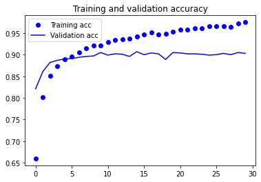

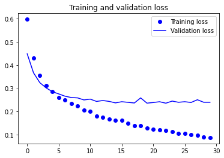

```python
import matplotlib.pyplot as plt

acc = history.history['acc']
val_acc = history.history['val_acc']
loss = history.history['loss']
val_loss = history.history['val_loss']

epochs = range(len(acc))

plt.plot(epochs, acc, 'bo', label='Training acc')
plt.plot(epochs, val_acc, 'b', label='Validation acc')
plt.title('Training and validation accuracy')
plt.legend()

plt.figure()
plt.plot(epochs, loss, 'bo', label='Training loss')
plt.plot(epochs, val_loss, 'b', label='Validation loss')
plt.title('Training and validation loss')
plt.legend()

plt.show()
```

### Summary

- validation 90%의 검증 정확도에 도달
- 앞에서 처음부터 훈련시킨 작은 모델에서 얻은 것보다 훨씬 좋음.
- 드롭아웃을 사용했음에도 불구하고 훈련이 시작하면서 거의 바로 과대적합되고 있다는 것
  - 과대적합의 이유 **작은 이미지 데이터셋**에서는 과대적합을 막기 위해 필수적인 데이터 증식을 사용하지 않음.

### REFERENCE

- keras applications : https://keras.io/api/applications/
- CNN의 이야기
  - https://engineer-mole.tistory.com/43
  - https://junklee.tistory.com/111